# UPA_projekt_0201

Tim 5: Lana Savić, Franka Marciuš, Lucijan Raspović, Martin Premar

2026-01-15

## 2.zadatak

```r
podaci <- read_excel("Online Retail_clean_2026.xlsx")
```

Učitavanje podataka

```r
tibble(podaci)
```

```
## # A tibble: 522,769 × 8
##    Invoice StockCode Description              Quantity InvoiceDate         Price
##    <chr>   <chr>     <chr>                       <dbl> <dttm>              <dbl>
##  1 489434  85048     "15CM CHRISTMAS GLASS B…       12 2009-12-01 07:45:00  6.95
##  2 489434  79323P    "PINK CHERRY LIGHTS"           12 2009-12-01 07:45:00  6.75
##  3 489434  79323W    "WHITE CHERRY LIGHTS"          12 2009-12-01 07:45:00  6.75
##  4 489434  22041     "RECORD FRAME 7\" SINGL…       48 2009-12-01 07:45:00  2.1
##  5 489434  21232     "STRAWBERRY CERAMIC TRI…       24 2009-12-01 07:45:00  1.25
##  6 489434  22064     "PINK DOUGHNUT TRINKET …       24 2009-12-01 07:45:00  1.65
##  7 489434  21871     "SAVE THE PLANET MUG"          24 2009-12-01 07:45:00  1.25
##  8 489434  21523     "FANCY FONT HOME SWEET …       10 2009-12-01 07:45:00  5.95
##  9 489435  22350     "CAT BOWL"                     12 2009-12-01 07:46:00  2.55
## 10 489435  22349     "DOG BOWL ; CHASING BAL…       12 2009-12-01 07:46:00  3.75
## # ℹ 522,759 more rows
## # ℹ 2 more variables: `Customer ID` <chr>, Country <chr>
```

```r
# provjera postojanja negativnih količina
podaci %>%
  filter(Quantity < 0) %>%
  nrow()
```

```
## [1] 12326
```

Postoji 12326 negativnih podataka.

```r
# provjera da li se negativne i pozitivne količine javljaju na istom računu
ProvjeriNegativne <- podaci %>%
  group_by(Invoice) %>%
  summarise(
    ImaNegativne = any(Quantity < 0),
    ImaPozitivne = any(Quantity > 0)
  ) %>%
  filter(ImaNegativne == TRUE & ImaPozitivne == TRUE)

nrow(ProvjeriNegativne)
```

```
## [1] 0
```

Rezultat je 0 što znači da ne postoje računi na kojima se mješaju i pozitivne i negativne vrijednosti, što znači da možemo obrisati račune koji imaju negativnu količinu.

Utvrđeno je da u skupu podataka postoje zapisi s negativnom količinom kupnje. Dodatnom analizom je pokazano da se negativne količine uvijek pojavljuju na posebnim računima, bez istovremenog pojavljivanja pozitivnih količina na istom računu. Takvi zapisi predstavljaju storna ili povrate kupnji te ne opisuju stvarnu kupovnu aktivnost kupaca. Zbog toga su redci s negativnim količinama uklonjeni iz daljnje analize.

```r
# uklanjanje zapisa s negativnom količinom
CistiPodaci <- podaci %>%
  filter(Quantity > 0)
```

```r
tibble(CistiPodaci)
```

```
## # A tibble: 510,443 × 8
##    Invoice StockCode Description              Quantity InvoiceDate         Price
##    <chr>   <chr>     <chr>                       <dbl> <dttm>              <dbl>
##  1 489434  85048     "15CM CHRISTMAS GLASS B…       12 2009-12-01 07:45:00  6.95
##  2 489434  79323P    "PINK CHERRY LIGHTS"           12 2009-12-01 07:45:00  6.75
##  3 489434  79323W    "WHITE CHERRY LIGHTS"          12 2009-12-01 07:45:00  6.75
##  4 489434  22041     "RECORD FRAME 7\" SINGL…       48 2009-12-01 07:45:00  2.1
##  5 489434  21232     "STRAWBERRY CERAMIC TRI…       24 2009-12-01 07:45:00  1.25
##  6 489434  22064     "PINK DOUGHNUT TRINKET …       24 2009-12-01 07:45:00  1.65
##  7 489434  21871     "SAVE THE PLANET MUG"          24 2009-12-01 07:45:00  1.25
##  8 489434  21523     "FANCY FONT HOME SWEET …       10 2009-12-01 07:45:00  5.95
##  9 489435  22350     "CAT BOWL"                     12 2009-12-01 07:46:00  2.55
## 10 489435  22349     "DOG BOWL ; CHASING BAL…       12 2009-12-01 07:46:00  3.75
## # ℹ 510,433 more rows
## # ℹ 2 more variables: `Customer ID` <chr>, Country <chr>
```

```r
# provjera broja anonimnih kupaca
CistiPodaci %>%
  filter(is.na(`Customer ID`)) %>%
  nrow()
```

```
## [1] 103488
```

Postoji 103.488 anonimnih kupaca (bez Customer ID-a).

```r
# uklanjanje anonimnih kupaca
CistiPodaci <- CistiPodaci %>%
  filter(!is.na(`Customer ID`))
```

```r
tibble(CistiPodaci)
```

```
## # A tibble: 406,955 × 8
##    Invoice StockCode Description              Quantity InvoiceDate         Price
##    <chr>   <chr>     <chr>                       <dbl> <dttm>              <dbl>
##  1 489434  85048     "15CM CHRISTMAS GLASS B…       12 2009-12-01 07:45:00  6.95
##  2 489434  79323P    "PINK CHERRY LIGHTS"           12 2009-12-01 07:45:00  6.75
##  3 489434  79323W    "WHITE CHERRY LIGHTS"          12 2009-12-01 07:45:00  6.75
##  4 489434  22041     "RECORD FRAME 7\" SINGL…       48 2009-12-01 07:45:00  2.1
##  5 489434  21232     "STRAWBERRY CERAMIC TRI…       24 2009-12-01 07:45:00  1.25
##  6 489434  22064     "PINK DOUGHNUT TRINKET …       24 2009-12-01 07:45:00  1.65
##  7 489434  21871     "SAVE THE PLANET MUG"          24 2009-12-01 07:45:00  1.25
##  8 489434  21523     "FANCY FONT HOME SWEET …       10 2009-12-01 07:45:00  5.95
##  9 489435  22350     "CAT BOWL"                     12 2009-12-01 07:46:00  2.55
## 10 489435  22349     "DOG BOWL ; CHASING BAL…       12 2009-12-01 07:46:00  3.75
## # ℹ 406,945 more rows
## # ℹ 2 more variables: `Customer ID` <chr>, Country <chr>
```

Uklonili smo sve račune na kojima je kupac anoniman odnosno vrijednost Customer ID je NA (nepostojeća). Vidimo da sada imamo 406.955 redaka.

Anonimni kupci uklonjeni su iz skupa podataka jer za njih nije moguće izračunati atribute na razini kupca niti pratiti kupovno ponašanje kroz više računa. Budući da se u nastavku analize izrađuju agregirani atributi kupaca te provode metode grupiranja, zapisi bez Customer ID-a ne bi imali smislen doprinos analizi i mogli bi narušiti rezultate.ć

```r
# provjera postojanja negativnih jediničnih cijena
CistiPodaci %>%
  filter(Price < 0) %>%
  nrow()
```

```
## [1] 0
```

Nakon prethodnih koraka čišćenja podataka, provjereno je postojanje zapisa s negativnom jediničnom cijenom u skupu podataka. Analizom je utvrđeno da ne postoje zapisi s negativnom jediničnom cijenom, budući da nijedan redak ne zadovoljava uvjet Price < 0.

S obzirom na to da takvi zapisi nisu prisutni u skupu podataka, nije bilo potrebe za dodatnim uklanjanjem podataka prema ovom kriteriju. Time se potvrđuje da su jedinične cijene konzistentne te da je skup podataka, nakon prethodnih koraka čišćenja, prikladan za daljnju deskriptivnu analizu i nastavak projekta.

```r
kupci <- CistiPodaci |>
  filter(Quantity > 0, Price > 0) |>

  # agregacija po kupcu i racunu
  group_by(`Customer ID`, Invoice) |>
  summarise(
    BrojKomada = sum(Quantity),
    Trosak = sum(Quantity * Price),
    BrojArtikala = n(),
    MaxPrice = max(Price),
    MinPrice = min(Price),
    MeanPrice = mean(Price),
    DatumRacuna = min(InvoiceDate),
    .groups = "drop"
  ) |>

  # agregacija po kupcu
  group_by(`Customer ID`) |>
  summarise(
    # 1
    BrojRacuna = n(),

    # 2
    UkupnoKomada = sum(BrojKomada),

    # 3
    UkupnaPotrosnja = sum(Trosak),

    # 4
    ProsjecnaPotrosnjaPoRacunu = mean(Trosak),

    # 5
    ProsjecanBrojArtikala = mean(BrojArtikala),

    # 6
    MaxPotrosnjaRacun = max(Trosak),

    # 7
    MinPotrosnjaRacun = min(Trosak),

    # 8
    MaxCijenaArtikla = max(MaxPrice),

    # 9
    MinCijenaArtikla = min(MinPrice),

    # 10
    ProsjecnaCijenaArtikla = mean(MeanPrice),

    # 11
    StdPotrosnje = sd(Trosak),

    # 12
    PrvaKupnja = min(DatumRacuna),

    # 13
    ZadnjaKupnja = max(DatumRacuna),

    # 14
    RasponKupnjeDana = as.numeric(max(DatumRacuna) - min(DatumRacuna)),

    # 15
    ProsjecnoKomadaPoRacunu = mean(BrojKomada),

    .groups = "drop"
  )
```

U daljnjoj analizi korišteni su isključivo zapisi s pozitivnom količinom i pozitivnom jediničnom cijenom. Zapisi s negativnom količinom predstavljaju povrate ili storna transakcija te ne opisuju stvarnu kupovnu aktivnost kupaca, dok negativna jedinična cijena nema poslovno značenje u kontekstu prodaje pojedinačnih artikala.

Uključivanje takvih zapisa moglo bi narušiti izračun ključnih atributa kupaca, poput ukupne i prosječne potrošnje, broja kupljenih artikala te vrijednosti računa, kao i dovesti do pogrešnih zaključaka u deskriptivnoj analizi i metodama grupiranja. Zbog toga su u analizu uključeni isključivo zapisi s pozitivnom količinom i cijenom, čime se osigurava konzistentnost, interpretabilnost i usporedivost dobivenih rezultata.

```r
KvantitativniKupci <- kupci |>
  dplyr::select(-`Customer ID`)

SummaryKvantitativniKupci <- KvantitativniKupci |>
  summarise(
    across(
      .cols = everything(),
      .fns = list(
        mean = ~mean(.x, na.rm = TRUE),
        median = ~median(.x, na.rm = TRUE),
        sd = ~sd(.x, na.rm = TRUE),
        IQR = ~IQR(.x, na.rm = TRUE),
        min = ~min(.x, na.rm = TRUE),
        max = ~max(.x, na.rm = TRUE),
        NA_count = ~sum(is.na(.x))
      ),
      .names = "{.col}_{.fn}"
    )
  )

SummaryKvantitativniKupci
```

```
## # A tibble: 1 × 105
##   BrojRacuna_mean BrojRacuna_median BrojRacuna_sd BrojRacuna_IQR BrojRacuna_min
##             <dbl>             <dbl>         <dbl>          <dbl>          <int>
## 1            4.44                 2          8.15              4              1
## # ℹ 100 more variables: BrojRacuna_max <int>, BrojRacuna_NA_count <int>,
## #   UkupnoKomada_mean <dbl>, UkupnoKomada_median <dbl>, UkupnoKomada_sd <dbl>,
## #   UkupnoKomada_IQR <dbl>, UkupnoKomada_min <dbl>, UkupnoKomada_max <dbl>,
## #   UkupnoKomada_NA_count <int>, UkupnaPotrosnja_mean <dbl>,
## #   UkupnaPotrosnja_median <dbl>, UkupnaPotrosnja_sd <dbl>,
## #   UkupnaPotrosnja_IQR <dbl>, UkupnaPotrosnja_min <dbl>,
## #   UkupnaPotrosnja_max <dbl>, UkupnaPotrosnja_NA_count <int>, …
```

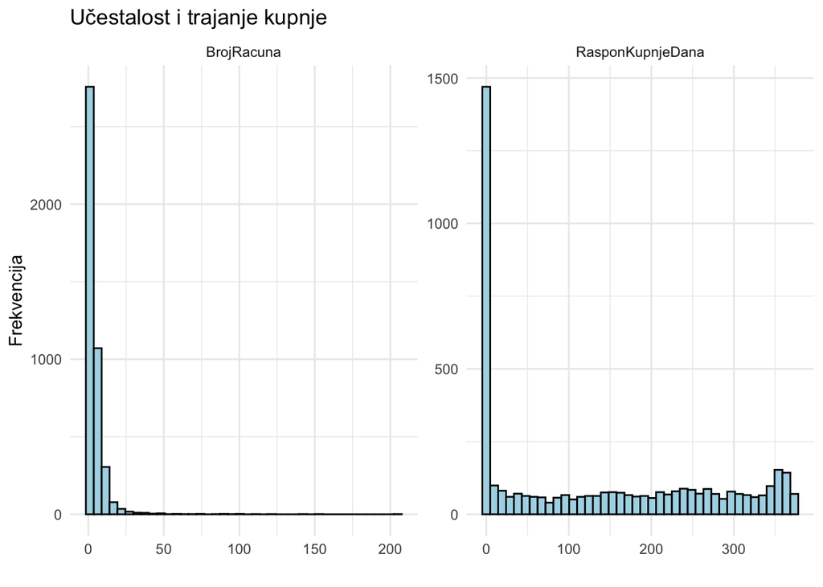

```r
kupci |>
  dplyr::select(BrojRacuna, RasponKupnjeDana) |>
  tidyr::pivot_longer(everything(), names_to = "var", values_to = "value") |>
  ggplot(aes(x = value)) +
  geom_histogram(bins = 40, fill = "lightblue", color = "black") +
  facet_wrap(~ var, scales = "free", ncol = 2) +
  labs(
    title = "Učestalost i trajanje kupnje",
    x = "",
    y = "Frekvencija"
  ) +
  theme_minimal()
```

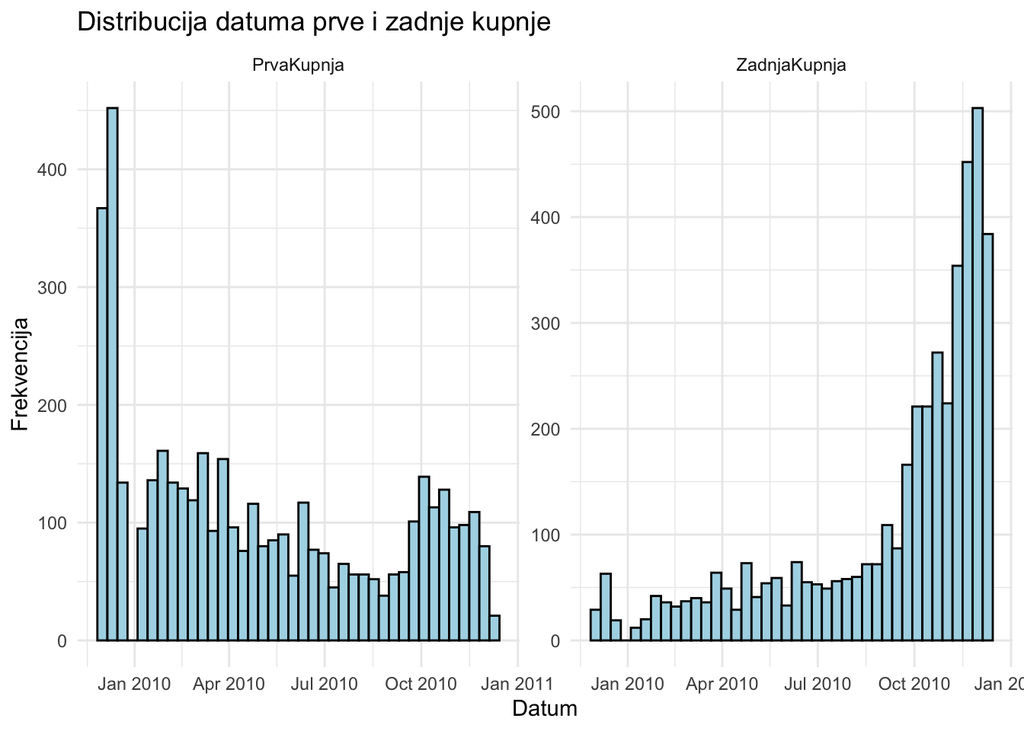

```r
kupci |>
  dplyr::select(PrvaKupnja, ZadnjaKupnja) |>
  tidyr::pivot_longer(
    everything(),
    names_to = "var",
    values_to = "value"
  ) |>
  ggplot(aes(x = value)) +
  geom_histogram(
    bins = 40,
    fill = "lightblue",
    color = "black"
  ) +
  facet_wrap(~ var, scales = "free", ncol = 2) +
  labs(
    title = "Distribucija datuma prve i zadnje kupnje",
    x = "Datum",
    y = "Frekvencija"
  ) +
  theme_minimal()
```

Varijabla PrvaKupnja opisuje datum kada je kupac prvi put ostvario kupnju. Distribucija pokazuje da se prve kupnje kupaca ne događaju ravnomjerno kroz cijelo promatrano razdoblje, već su koncentrirane u određenim vremenskim intervalima. To upućuje na razdoblja intenzivnijeg priljeva novih kupaca, što može biti povezano s marketinškim aktivnostima, širenjem ponude ili sezonskim utjecajima. Distribucija je unimodalna s izraženijim koncentracijama u pojedinim razdobljima, bez ekstremnih stršila.

Varijabla ZadnjaKupnja opisuje datum kada je kupac posljednji put ostvario kupnju. Distribucija pokazuje da se velik broj zadnjih kupnji nalazi bliže novijim datumima, što ukazuje na postojanje aktivne baze kupaca. Istovremeno, dio kupaca ima zadnju kupnju u znatno ranijem razdoblju, što upućuje na kupce koji više nisu aktivni. Raspodjela je blago do umjereno asimetrična prema ranijim datumima, bez izrazitih stršila, te jasno pokazuje razliku između aktivnih i neaktivnih kupaca.

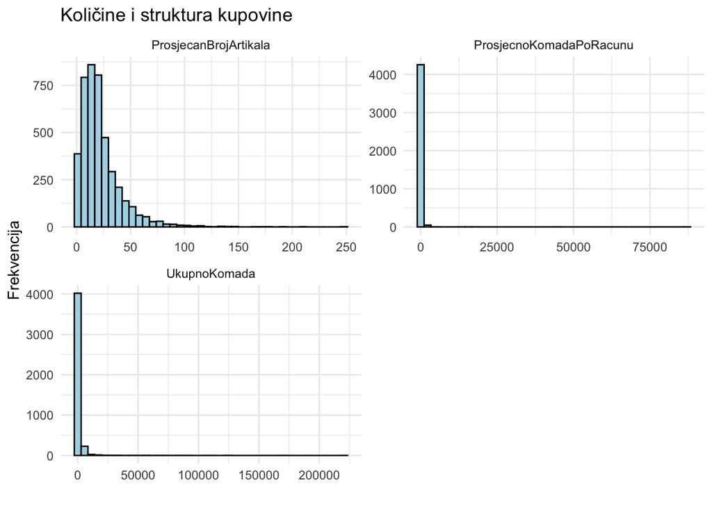

```r
kupci |>
  dplyr::select(UkupnoKomada, ProsjecnoKomadaPoRacunu, ProsjecanBrojArtikala) |>
  tidyr::pivot_longer(everything(), names_to = "var", values_to = "value") |>
  ggplot(aes(x = value)) +
  geom_histogram(bins = 40, fill = "lightblue", color = "black") +
  facet_wrap(~ var, scales = "free", ncol = 2) +
  labs(
    title = "Količine i struktura kupovine",
    x = "",
    y = "Frekvencija"
  ) +
  theme_minimal()
```

Varijabla UkupnoKomada opisuje ukupan broj kupljenih komada po kupcu. Distribucija je izrazito desno asimetrična, što znači da većina kupaca kupuje relativno mali broj artikala, dok manji broj kupaca ostvaruje vrlo velike količine kupnje. Histogram je unimodalan i iskrivljen u desno. Prisutna su stršila s desne strane distribucije koja ukazuju na kupce s iznimno velikim ukupnim brojem kupljenih artikala. Medijan je manji od aritmetičke sredine, što dodatno potvrđuje postojanje kupaca s ekstremnim vrijednostima.

Varijabla ProsjecnoKomadaPoRacunu opisuje prosječan broj kupljenih komada po jednom računu. Distribucija je desno asimetrična i unimodalna, pri čemu se najveći broj kupaca nalazi u donjem dijelu raspodjele. Većina kupaca po računu kupuje manji broj komada, dok se manji broj kupaca ističe većim prosječnim količinama kupnje.

Varijabla ProsjecanBrojArtikala opisuje prosječan broj različitih artikala po računu. Distribucija je blago do umjereno desno asimetrična i unimodalna. Većina kupaca na jednom računu kupuje ograničen broj različitih artikala, dok manji broj kupaca ima raznovrsnije košarice. Stršila su prisutna, ali nisu ekstremna, što upućuje na to da se struktura kupovine među kupcima razlikuje, ali bez izrazito ekstremnih obrazaca.

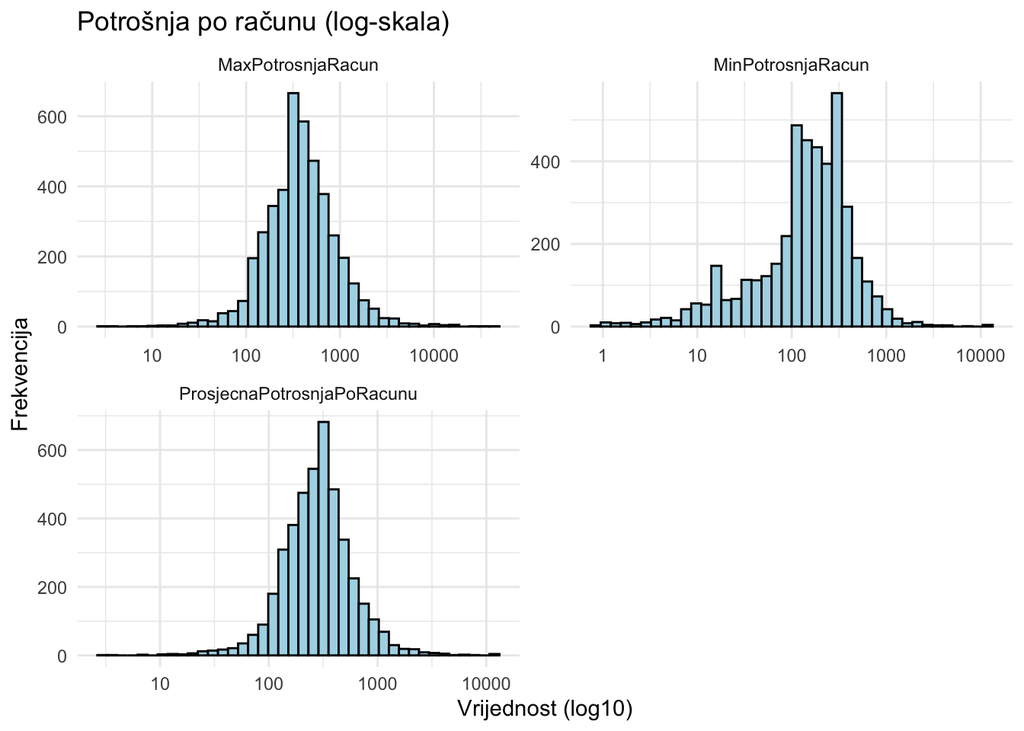

```r
kupci |>
  dplyr::select(ProsjecnaPotrosnjaPoRacunu, MaxPotrosnjaRacun, MinPotrosnjaRacun) |>
  tidyr::pivot_longer(everything(), names_to = "var", values_to = "value") |>
  ggplot(aes(x = value)) +
  geom_histogram(bins = 40, fill = "lightblue", color = "black") +
  scale_x_log10() +
  facet_wrap(~ var, scales = "free", ncol = 2) +
  labs(
    title = "Potrošnja po računu (log-skala)",
    x = "Vrijednost (log10)",
    y = "Frekvencija"
  ) +
  theme_minimal()
```

Varijabla ProsjecnaPotrosnjaPoRacunu opisuje prosječni iznos potrošnje koji kupac ostvaruje po jednom računu. Distribucija je izrazito desno asimetrična i unimodalna. Većina kupaca ostvaruje relativno nisku prosječnu potrošnju po računu, dok manji broj kupaca ima znatno veće iznose potrošnje. Prisutna su stršila s desne strane distribucije, što ukazuje na račune s izrazito visokom vrijednošću. Medijan je manji od aritmetičke sredine, što potvrđuje utjecaj visokih iznosa na prosječnu vrijednost.

Varijabla MaxPotrosnjaRacun opisuje najveći iznos potrošnje koji je kupac ostvario na pojedinačnom računu. Distribucija je izrazito desno asimetrična i unimodalna. Većina kupaca ima relativno nizak maksimalni iznos potrošnje, dok se manji broj kupaca ističe vrlo skupim računima. Prisutna su izražena stršila s desne strane distribucije, koja predstavljaju iznimno vrijedne kupovine.

Varijabla MinPotrosnjaRacun opisuje najmanji iznos potrošnje po računu. Distribucija je također desno asimetrična i unimodalna, ali s manjim rasponom vrijednosti u odnosu na ostale varijable u ovoj grupi. Većina kupaca ima nisku minimalnu potrošnju po računu, dok su stršila rijetka i manje izražena, što upućuje na to da gotovo svi kupci barem jednom ostvaruju kupnju slične, relativno niske vrijednosti.

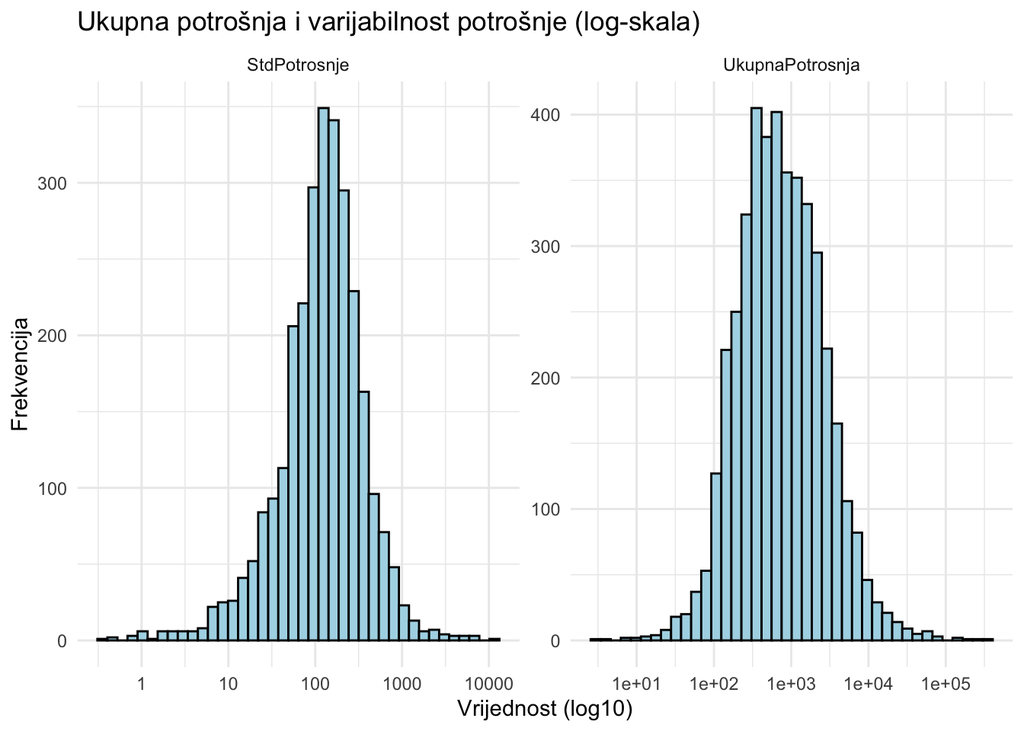

```r
kupci |>
  dplyr::select(UkupnaPotrosnja, StdPotrosnje) |>
  tidyr::pivot_longer(everything(), names_to = "var", values_to = "value") |>
  ggplot(aes(x = value)) +
  geom_histogram(bins = 40, fill = "lightblue", color = "black") +
  scale_x_log10() +
  facet_wrap(~ var, scales = "free", ncol = 2) +
  labs(
    title = "Ukupna potrošnja i varijabilnost potrošnje (log-skala)",
    x = "Vrijednost (log10)",
    y = "Frekvencija"
  ) +
  theme_minimal()
```

Varijabla UkupnaPotrosnja opisuje ukupni iznos koji je kupac potrošio u cijelom razdoblju promatranja. Distribucija je izrazito desno asimetrična, što znači da većina kupaca ostvaruje relativno nisku ukupnu potrošnju, dok manji broj kupaca ostvaruje vrlo velike iznose potrošnje. Histogram je unimodalan i iskrivljen u desno. Prisutna su izražena stršila s desne strane distribucije koja predstavljaju kupce s iznimno velikom ukupnom potrošnjom. Medijan je manji od aritmetičke sredine, što potvrđuje da ekstremno veliki iznosi značajno utječu na prosječnu vrijednost.

Varijabla StdPotrosnje opisuje varijabilnost potrošnje kupca po računima, odnosno koliko se iznosi računa razlikuju kroz vrijeme. Distribucija je desno asimetrična i unimodalna. Većina kupaca ima nisku varijabilnost potrošnje, što znači da kupuju u relativno sličnim iznosima, dok manji broj kupaca ima vrlo promjenjive iznose računa. Histogram je iskrivljen u desno, a prisutna su stršila s desne strane koja ukazuju na kupce kod kojih se povremeno javljaju izrazito veliki računi u odnosu na njihove uobičajene kupnje. Medijan je manji od aritmetičke sredine, što je očekivano zbog utjecaja kupaca s visokom varijabilnošću.

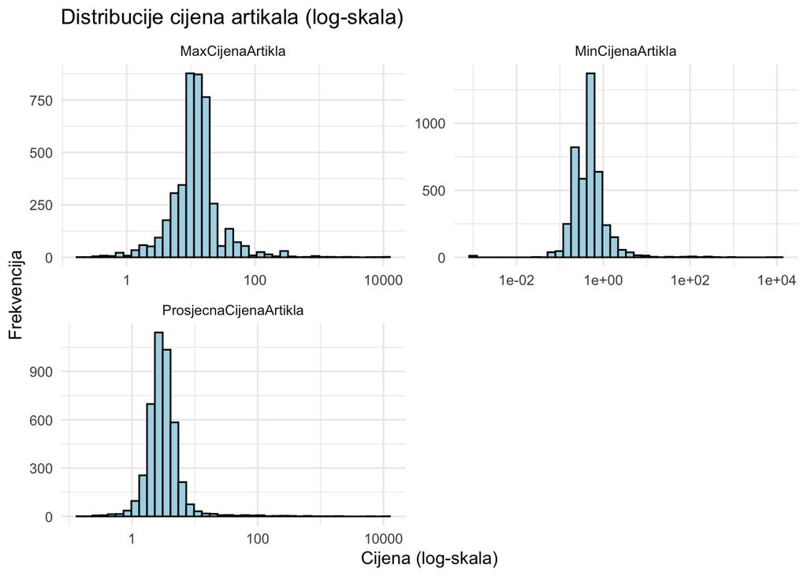

```r
kupci |>
  dplyr::select(MinCijenaArtikla, ProsjecnaCijenaArtikla, MaxCijenaArtikla) |>
  tidyr::pivot_longer(everything(), names_to = "var", values_to = "value") |>
  ggplot(aes(x = value)) +
  geom_histogram(bins = 40, fill = "lightblue", color = "black") +
  scale_x_log10() +
  facet_wrap(~ var, scales = "free", ncol = 2) +
  labs(
    title = "Distribucije cijena artikala (log-skala)",
    x = "Cijena (log-skala)",
    y = "Frekvencija"
  ) +
  theme_minimal()
```

Varijabla MinCijenaArtikla opisuje najnižu jediničnu cijenu artikla koju je kupac kupovao. Distribucija je blago do umjereno desno asimetrična i unimodalna. Većina kupaca kupuje barem jedan vrlo jeftin artikl, dok manji broj kupaca ima višu minimalnu cijenu kupljenih artikala. Stršila nisu izrazito naglašena, što upućuje na relativno slične minimalne cijene među većinom kupaca.

Varijabla ProsjecnaCijenaArtikla opisuje prosječnu jediničnu cijenu artikala koje kupac kupuje. Distribucija je desno asimetrična i unimodalna. Većina kupaca kupuje artikle nižeg do srednjeg cjenovnog razreda, dok manji broj kupaca u prosjeku kupuje skuplje artikle. Prisutna su stršila s desne strane distribucije, ali nisu ekstremna, što ukazuje na postojanje kupaca s nešto skupljim košaricama, ali bez izrazito rijetkih ekstremnih vrijednosti.

Varijabla MaxCijenaArtikla opisuje najvišu jediničnu cijenu artikla koju je kupac kupovao. Distribucija je izrazito desno asimetrična i unimodalna. Većina kupaca kupuje artikle umjerenih cijena, dok manji broj kupaca povremeno kupuje vrlo skupe artikle. Prisutna su izražena stršila s desne strane distribucije, koja predstavljaju kupce koji su barem jednom kupili artikl izrazito visoke cijene. Medijan je manji od aritmetičke sredine, što potvrđuje utjecaj skupih artikala na prosječnu vrijednost.

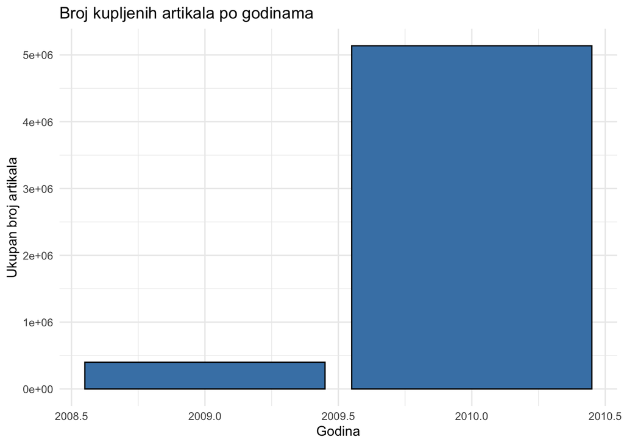

```r
ArtikliGodine <- CistiPodaci |>
  mutate(Godina = year(InvoiceDate)) |>
  group_by(Godina) |>
  summarise(BrojArtikala = sum(Quantity))

ggplot(ArtikliGodine, aes(x = Godina, y = BrojArtikala)) +
  geom_col(fill = "steelblue", color = "black") +
  labs(
    title = "Broj kupljenih artikala po godinama",
    x = "Godina",
    y = "Ukupan broj artikala"
  ) +
  theme_minimal()
```

Gikazuje ukupan broj kupljenih artikala po godinama. Vidljivo je da se intenzitet kupovine razlikuje između godina, što upućuje na promjene u obujmu poslovanja kroz vrijeme. U pojedinim godinama zabilježen je znatno veći broj kupljenih artikala, dok su druge godine slabije zastupljene. Ovakav obrazac može biti posljedica rasta poslovanja, sezonalnosti, ali i nepotpunosti podataka za pojedine godine. Analiza po godinama daje osnovni uvid u dugoročni trend kupovine.

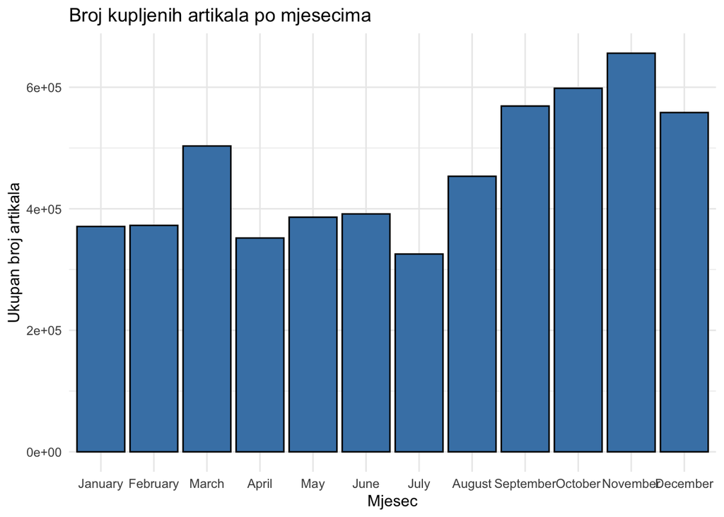

```r
ArtikliMjeseci <- CistiPodaci |>
  mutate(Mjesec = month(InvoiceDate, label = TRUE, abbr = FALSE)) |>
  group_by(Mjesec) |>
  summarise(BrojArtikala = sum(Quantity))

ggplot(ArtikliMjeseci, aes(x = Mjesec, y = BrojArtikala)) +
  geom_col(fill = "steelblue", color = "black") +
  labs(
    title = "Broj kupljenih artikala po mjesecima",
    x = "Mjesec",
    y = "Ukupan broj artikala"
  ) +
  theme_minimal()
```

Graf prikazuje ukupan broj kupljenih artikala po mjesecima u godini. Vidljivo je da kupovina nije ravnomjerno raspoređena kroz godinu, već pokazuje izražene sezonske obrasce. U pojedinim mjesecima zabilježen je znatno veći broj kupljenih artikala, dok su neki mjeseci slabije zastupljeni. Ovakav obrazac može se objasniti sezonalnošću potražnje, blagdanskim razdobljima te promotivnim aktivnostima koje utječu na intenzitet kupovine tijekom godine.

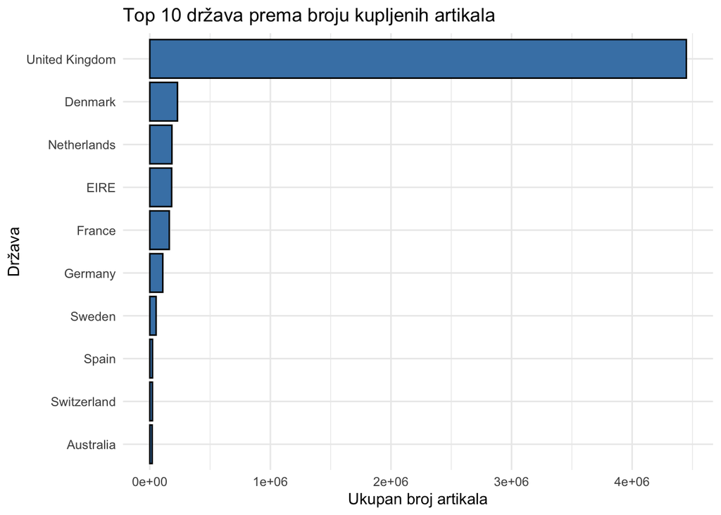

```r
ArtikliDrzave <- CistiPodaci |>
  group_by(Country) |>
  summarise(BrojArtikala = sum(Quantity)) |>
  arrange(desc(BrojArtikala)) |>
  slice_head(n = 10)

ggplot(ArtikliDrzave, aes(x = reorder(Country, BrojArtikala), y = BrojArtikala)) +
  geom_col(fill = "steelblue", color = "black") +
  coord_flip() +
  labs(
    title = "Top 10 država prema broju kupljenih artikala",
    x = "Država",
    y = "Ukupan broj artikala"
  ) +
  theme_minimal()
```

Graf prikazuje deset država s najvećim ukupnim brojem kupljenih artikala. Vidljivo je da je kupovina snažno koncentrirana u nekoliko država, dok ostale zemlje imaju znatno manji udio u ukupnom broju prodanih artikala. Ovakva raspodjela upućuje na postojanje ključnih tržišta na kojima je poslovanje najintenzivnije. Velik broj slabije zastupljenih država opravdava ograničavanje grafičkog prikaza na najvažnije kategorije kako bi se osigurala preglednost i informativnost analize.

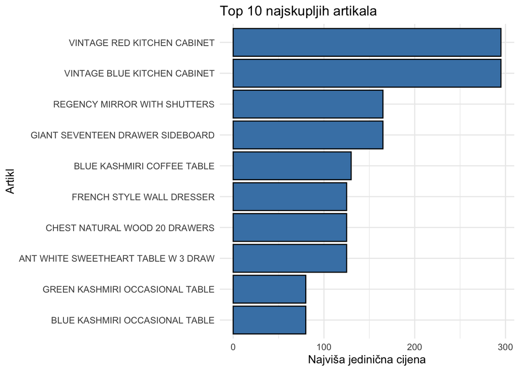

```r
TopSkuplji <- CistiPodaci |>
  filter(
    !str_detect(tolower(Description), "manual"),
    !str_detect(tolower(Description), "adjustment"),
    !str_detect(tolower(Description), "discount"),
    !str_detect(tolower(Description), "postage"),
    !str_detect(tolower(Description), "carriage"),
    !str_detect(tolower(Description), "bank")

  ) |>
  group_by(Description) |>
  summarise(MaxCijena = max(Price)) |>
  arrange(desc(MaxCijena)) |>
  slice_head(n = 10)

ggplot(TopSkuplji, aes(x = reorder(Description, MaxCijena), y = MaxCijena)) +
  geom_col(fill = "steelblue", color = "black") +
  coord_flip() +
  labs(
    title = "Top 10 najskupljih artikala",
    x = "Artikl",
    y = "Najviša jedinična cijena"
  ) +
  theme_minimal()
```

Graf prikazuje deset artikala s najvišom zabilježenom jediničnom cijenom, pri čemu se jasno ističu artikli iz kategorije namještaja, poput kuhinjskih ormarića, komoda i stolova. Prije izrade rang-liste iz analize su uklonjene stavke koje ne predstavljaju stvarne proizvode, poput zapisa “Manual”, “Adjustment”, “Discount”, “Postage” i sličnih administrativnih unosa, jer se odnose na interne korekcije i logističke troškove. Njihovo uključivanje bi dovelo do pogrešne interpretacije cjenovne strukture asortimana.

Nakon uklanjanja navedenih zapisa, vidljivo je da najskuplji artikli imaju znatno višu cijenu u odnosu na ostatak ponude, što upućuje na postojanje premium segmenta u asortimanu trgovine. Razlike u cijenama među prikazanim artiklima su izražene, što potvrđuje heterogenost ponude u pogledu cjenovnog raspona. Iako se radi o artiklima s visokim jediničnim cijenama, njihov količinski udio u ukupnoj prodaji vjerojatno je manji, ali mogu imati značajan doprinos ukupnoj vrijednosti prodaje.

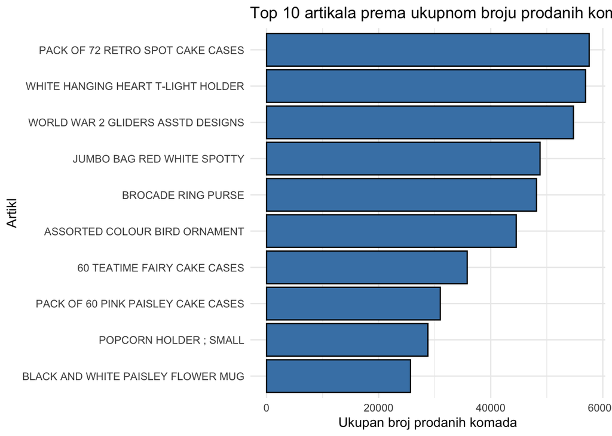

```r
TopKupovani <- CistiPodaci |>
  filter(
    !str_detect(tolower(Description), "manual"),
    !str_detect(tolower(Description), "adjustment"),
    !str_detect(tolower(Description), "discount"),
    !str_detect(tolower(Description), "postage"),
    !str_detect(tolower(Description), "carriage"),
    !str_detect(tolower(Description), "bank")
  ) |>
  group_by(Description) |>
  summarise(UkupnoKomada = sum(Quantity)) |>
  arrange(desc(UkupnoKomada)) |>
  slice_head(n = 10)

ggplot(TopKupovani, aes(x = reorder(Description, UkupnoKomada), y = UkupnoKomada)) +
  geom_col(fill = "steelblue", color = "black") +
  coord_flip() +
  labs(
    title = "Top 10 artikala prema ukupnom broju prodanih komada",
    x = "Artikl",
    y = "Ukupan broj prodanih komada"
  ) +
  theme_minimal()
```

Graf prikazuje deset artikala s najvećim ukupnim brojem prodanih komada. Vidljivo je da se najviše kupuju artikli s nižom jediničnom cijenom i širokom primjenom, koji su često dio svakodnevne ili sezonske potrošnje. U usporedbi s rang-listom najskupljih artikala, ovdje dominiraju proizvodi koji se prodaju u velikim količinama, ali po znatno nižim cijenama.

Prije izrade rang-liste kao i kod predhodne za najskuplje proizvode iz analize su uklonjene administrativne i logističke stavke koje ne predstavljaju stvarne proizvode, kako bi prikaz odražavao stvarne kupovne navike. Ovakva rang-lista daje uvid u artikle koji generiraju najveći volumen prodaje te su ključni za operativno poslovanje trgovine.

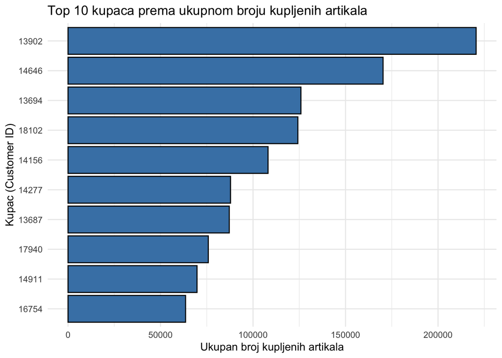

```r
TopKupci <- CistiPodaci |>
  group_by(`Customer ID`) |>
  summarise(UkupnoKomada = sum(Quantity)) |>
  arrange(desc(UkupnoKomada)) |>
  slice_head(n = 10)

ggplot(TopKupci,
       aes(x = reorder(as.factor(`Customer ID`), UkupnoKomada),
           y = UkupnoKomada)) +
  geom_col(fill = "steelblue", color = "black") +
  coord_flip() +
  labs(
    title = "Top 10 kupaca prema ukupnom broju kupljenih artikala",
    x = "Kupac (Customer ID)",
    y = "Ukupan broj kupljenih artikala"
  ) +
  theme_minimal()
```

Graf prikazuje deset kupaca s najvećim ukupnim brojem kupljenih artikala. Vidljivo je da se mali broj kupaca izrazito izdvaja po volumenu kupnje u odnosu na ostale, što upućuje na postojanje vrlo aktivnih ili poslovnih kupaca. Razlike između prvih nekoliko kupaca i ostatka rang-liste su značajne, što pokazuje da kupovina nije ravnomjerno raspoređena među kupcima. Ovakav obrazac je očekivan u maloprodajnim podacima te je važan s poslovnog aspekta jer mali broj ključnih kupaca može generirati velik dio ukupnog volumena prodaje.

## 3.zadatak

```r
#Priprema podataka na razinu kupca (1 red = 1 kupac)
referentni_datum <- as.Date("2026-01-15")

AtributiKupaca <- CistiPodaci %>%
  group_by(`Customer ID`) %>%
  summarise(
    BrojRacuna = n_distinct(Invoice),
    BrojKomada = sum(Quantity),
    BrojRazlicitihArtikala = n_distinct(Description),
    UkupnaPotrosnja = sum(Quantity * Price),
    DaniOdZadnjeKupnje = as.numeric(difftime(referentni_datum, max(InvoiceDate), units = "days")),
    ProsjecnaVrijednostRacuna = sum(Quantity * Price) / n_distinct(Invoice),
    ProsjecnaCijenaArtikla = sum(Quantity * Price) / sum(Quantity),
    .groups = "drop"
  )

summary(AtributiKupaca)
```

```
##  Customer ID          BrojRacuna        BrojKomada       BrojRazlicitihArtikala
##  Length:4310        Min.   :  1.000   Min.   :     1.0   Min.   :   1.00
##  Class :character   1st Qu.:  1.000   1st Qu.:   158.0   1st Qu.:  17.00
##  Mode  :character   Median :  2.000   Median :   382.0   Median :  38.00
##                     Mean   :  4.444   Mean   :  1284.7   Mean   :  63.62
##                     3rd Qu.:  5.000   3rd Qu.:   996.8   3rd Qu.:  79.00
##                     Max.   :205.000   Max.   :220596.0   Max.   :1741.00
##  UkupnaPotrosnja     DaniOdZadnjeKupnje ProsjecnaVrijednostRacuna
##  Min.   :     2.95   Min.   :5515       Min.   :    2.95
##  1st Qu.:   307.39   1st Qu.:5533       1st Qu.:  181.65
##  Median :   695.92   Median :5567       Median :  285.79
##  Mean   :  2037.88   Mean   :5606       Mean   :  378.41
##  3rd Qu.:  1708.76   3rd Qu.:5651       3rd Qu.:  421.79
##  Max.   :349164.35   Max.   :5889       Max.   :11880.84
##  ProsjecnaCijenaArtikla
##  Min.   :1.363e-01
##  1st Qu.:1.442e+00
##  Median :1.853e+00
##  Mean   :8.410e+00
##  3rd Qu.:2.405e+00
##  Max.   :1.095e+04
```

Podaci su agregirani tako da svaki red predstavlja jednog kupca. Dodana je varijabla DaniOdZadnjeKupnje koja je nužna za RFM analizu (da vidimo je li kupac aktivan ili nas je napustio).

```r
#Uklanjanje stršila
AtributiBezStrsila <- AtributiKupaca %>%
  filter(
    UkupnaPotrosnja < quantile(UkupnaPotrosnja, 0.99, na.rm = TRUE),
    BrojKomada < quantile(BrojKomada, 0.99, na.rm = TRUE),
    BrojRacuna < quantile(BrojRacuna, 0.99, na.rm = TRUE)
  )

nrow(AtributiKupaca)
```

```
## [1] 4310
```

```r
nrow(AtributiBezStrsila)
```

```
## [1] 4237
```

Na temelju deskriptivne analize koju smo proveli u drugom zadatku, vidjeli smo da distribucije imaju dugačak rep, postoji mali broj kupaca s ekstremno visokim vrijednostima. Zato smo ovdje uklonili gornjih 1% kupaca tj. stršila. K-means metoda je jako osjetljiva na takva odstupanja jer ona pomiču središta klastera, pa bi nam rezultati bili iskrivljeni ako ih ostavimo.

```r
#Skupovi za k-means (bez ID-a, normalizirani, log+normalizirani)

SkupZaKlasteriranje <- AtributiBezStrsila %>%
  select(UkupnaPotrosnja, BrojRacuna, DaniOdZadnjeKupnje, ProsjecnaCijenaArtikla)

# Normalizacija
SkupNormalizirani <- scale(SkupZaKlasteriranje)

# Logaritam smanjuje utjecaj ekstrema i spričava pojavu klastera od 2 kupca
SkupLogNormalizirani <- SkupZaKlasteriranje %>%
  mutate(across(everything(), log1p)) %>%
  scale()
```

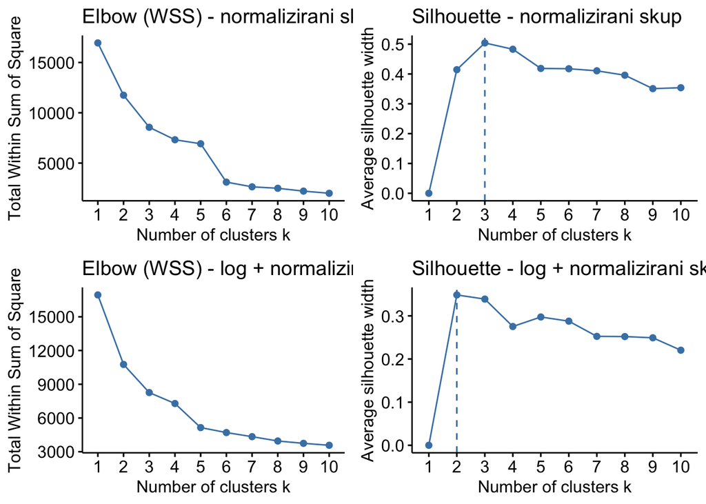

```r
#Odabir broja klastera (WSS/Elbow i Silhouette)
GrafWssNorm <- fviz_nbclust(SkupNormalizirani, kmeans, method = "wss") +
  ggtitle("Elbow (WSS) - normalizirani skup")

GrafSilNorm <- fviz_nbclust(SkupNormalizirani, kmeans, method = "silhouette") +
  ggtitle("Silhouette - normalizirani skup")

GrafWssLog <- fviz_nbclust(SkupLogNormalizirani, kmeans, method = "wss") +
  ggtitle("Elbow (WSS) - log + normalizirani skup")

GrafSilLog <- fviz_nbclust(SkupLogNormalizirani, kmeans, method = "silhouette") +
  ggtitle("Silhouette - log + normalizirani skup")

grid.arrange(GrafWssNorm, GrafSilNorm, GrafWssLog, GrafSilLog, ncol = 2)
```

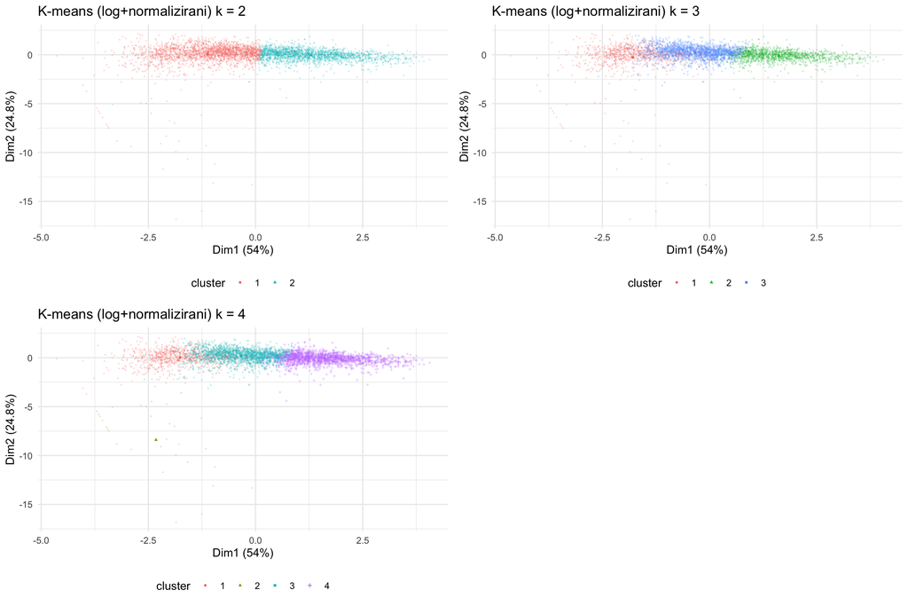

```r
#K-means za više vrijednosti k (2–6) i vizualizacije
set.seed(123)

ListaKPrikaz <- c(2, 3, 4)

VizualizaCijeLog <- lapply(ListaKPrikaz, function(k) {
  set.seed(123)
  Model <- kmeans(SkupLogNormalizirani, centers = k, nstart = 25)

  fviz_cluster(
    Model,
    data = SkupLogNormalizirani,
    geom = "point",
    labelsize = 0,
    pointsize = 0.4,
    alpha = 0.25,
    ellipse = FALSE
  ) +
    ggtitle(paste0("K-means (log+normalizirani) k = ", k)) +
    theme_minimal() +
    theme(legend.position = "bottom")
})

do.call(grid.arrange, c(VizualizaCijeLog, ncol = 2))
```

Prikazane su podjele na 2, 3 i 4 grupe. Vizualno, podjela na 3 grupe djeluje najlogičnije jer se grupe ne preklapaju previše, a pokrivaju različite segmente podataka. Podaci su prikazani na dvije glavne komponente jer imamo više varijabli.

```r
#Finalni odabir k i konačni modeli
kFinal <- 3

set.seed(123)
KmeansFinalNorm <- kmeans(SkupNormalizirani, centers = kFinal, nstart = 25)

set.seed(123)
KmeansFinalLog <- kmeans(SkupLogNormalizirani, centers = kFinal, nstart = 25)

# Velicine klastera
VelicineKlasteraNorm <- table(KmeansFinalNorm$cluster)
VelicineKlasteraLog <- table(KmeansFinalLog$cluster)

VelicineKlasteraNorm
```

```
##
##    1    2    3
## 2767 1009  461
```

```r
VelicineKlasteraLog
```

```
##
##    1    2    3
##  964 1445 1828
```

Kao što vidimo iz tablice, klasteri nisu jednake veličine ali su bolje rasopoređeni zbog logaritamske transformacije i našem odabiru varijabli. To je očekivano u prodaji, obično postoji jedna velika grupa povremenih kupaca i jedna manja grupa onih koji troše puno i stalno. Isto tako i zbog toga nemamo više ekstremno male grupe.

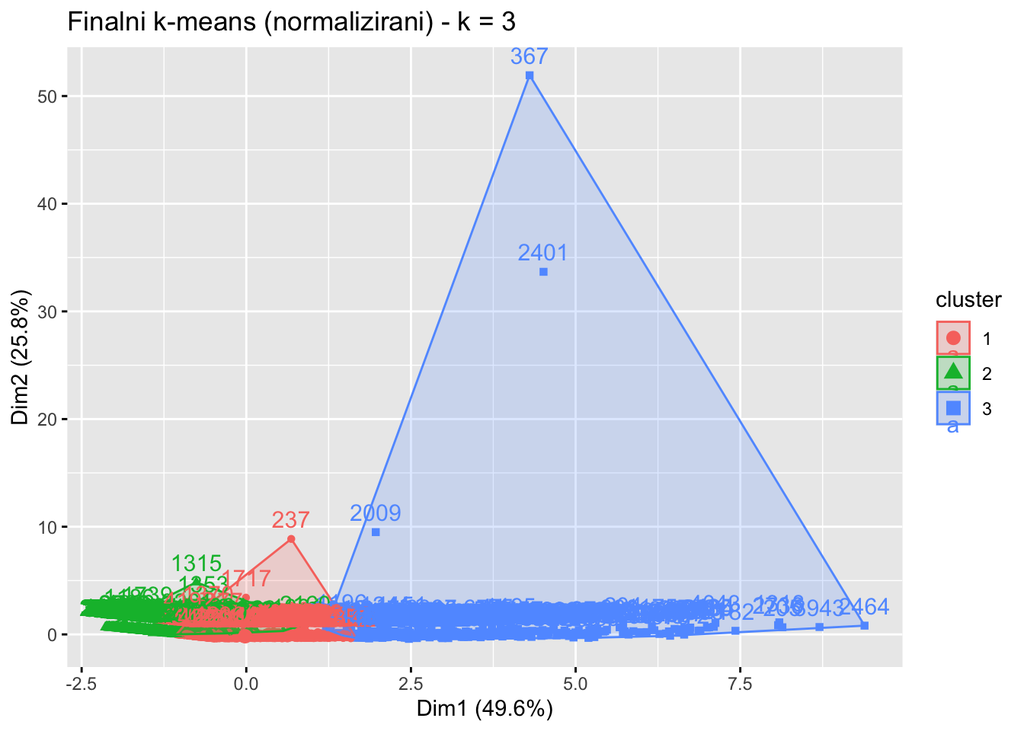

```r
#Vizualizacija(normalizirani i log skup)
fviz_cluster(KmeansFinalNorm, data = SkupNormalizirani) +
  ggtitle(paste0("Finalni k-means (normalizirani) - k = ", kFinal))
```

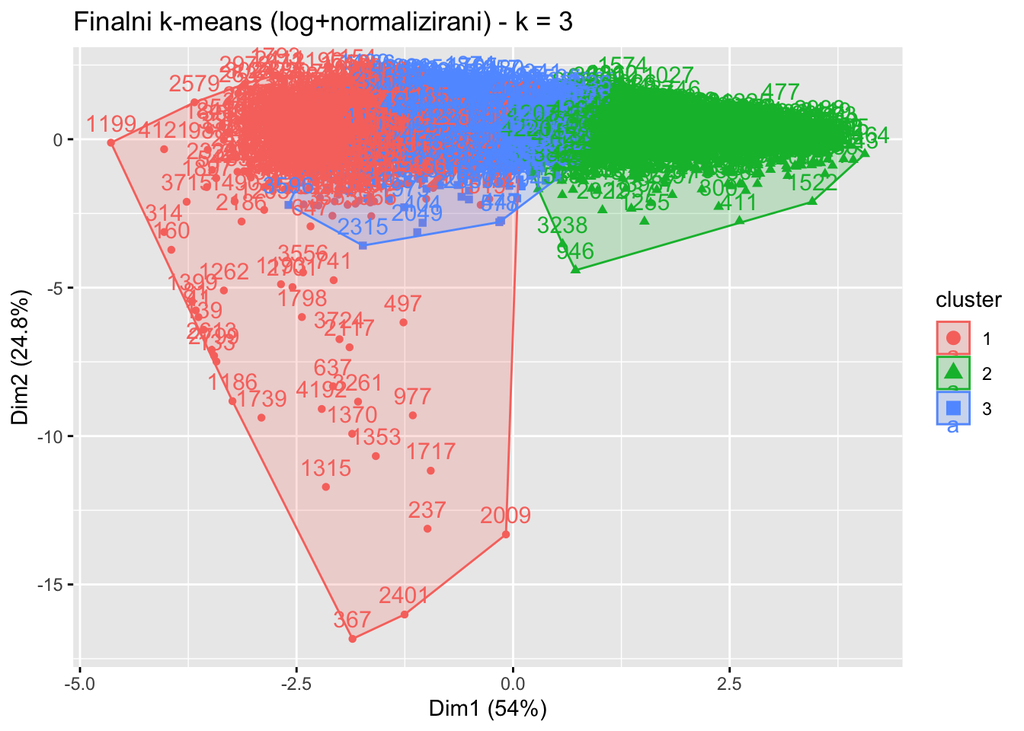

```r
fviz_cluster(KmeansFinalLog, data = SkupLogNormalizirani) +
  ggtitle(paste0("Finalni k-means (log+normalizirani) - k = ", kFinal))
```

```r
#Interpretacija klastera
AtributiSklasteromNorm <- AtributiBezStrsila %>%
  mutate(Klaster = KmeansFinalNorm$cluster)

ProfilKlasteraNorm <- AtributiSklasteromNorm %>%
  group_by(Klaster) %>%
  summarise(
    BrojKupaca = n(),
    UkupnaPotrosnja = mean(UkupnaPotrosnja),
    BrojRacuna = mean(BrojRacuna),
    BrojKomada = mean(BrojKomada),
    DaniOdZadnjeKupnje = mean(DaniOdZadnjeKupnje),
    ProsjecnaCijenaArtikla = mean(ProsjecnaCijenaArtikla),
    .groups = "drop"
  )

print(ProfilKlasteraNorm)
```

```
## # A tibble: 3 × 7
##   Klaster BrojKupaca UkupnaPotrosnja BrojRacuna BrojKomada DaniOdZadnjeKupnje
##     <int>      <int>           <dbl>      <dbl>      <dbl>              <dbl>
## 1       1       2767           1023.       3.15       615.              5562.
## 2       2       1009            446.       1.53       254.              5759.
## 3       3        461           5600.      12.2       2997.              5540.
## # ℹ 1 more variable: ProsjecnaCijenaArtikla <dbl>
```

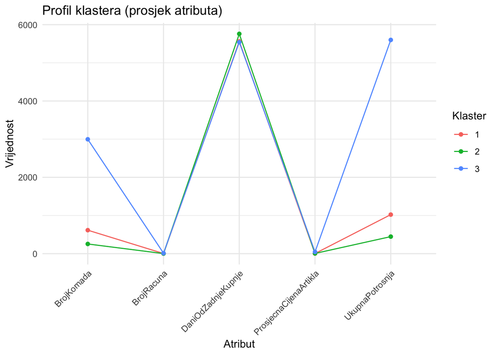

```r
# Vizualizacija
ProfilLongNorm <- ProfilKlasteraNorm %>%
  select(-BrojKupaca) %>%
  pivot_longer(cols = -Klaster, names_to = "Atribut", values_to = "Vrijednost")

ggplot(ProfilLongNorm, aes(x = Atribut, y = Vrijednost, group = Klaster, color = factor(Klaster))) +
  geom_line() +
  geom_point() +
  theme_minimal() +
  theme(axis.text.x = element_text(angle = 45, hjust = 1)) +
  labs(color = "Klaster") +
  ggtitle("Profil klastera (prosjek atributa)")
```

Potpuna suprotnost njima je druga skupina neaktivnih kupaca. Njihova glavna karakteristika nije iznos koji su potrošili, već vrijeme. Podaci pokazuju da je kod njih prošlo jako puno dana od zadnje transakcije, što znači da nisu posjetili već jako dugo. Dok su bili aktivni, trošili su relativno malo novaca. Vjerojatno se radi o ljudima koji su nekad nešto kupili, ali su u međuvremenu prestali dolaziti, pa bi ih možda trebalo pokušati reaktivirati nekom posebnom ponudom.

Između te dvije skupine nalaze se oni prosječni, povremeni kupci. Primijetili smo da oni kupuju redovito, ali u manjim količinama i ne troše velike iznose odjednom kao ona prva grupa. Ipak, oni su važni jer su brojni i čine stabilnu bazu poslovanja. Kod njih nema nekih ekstrema, aktivni su, ali jednostavno kupuju manje stvari po jednom dolasku.

## 4.Zadatak

```r
#Priprema udaljenosti
Udaljenosti <- dist(SkupLogNormalizirani, method = "euclidean")
```

```r
#Model s tri različite metode povezivanja

#Metoda potpunog povezivanja/najudaljenijih susjeda
HC_Complete <- hclust(Udaljenosti, method = "complete")

#Metoda prosječnog povezivanja
HC_Average <- hclust(Udaljenosti, method = "average")

#Wardova metoda minimizira varijancu unutar klastera)
HC_Ward <- hclust(Udaljenosti, method = "ward.D2")
```

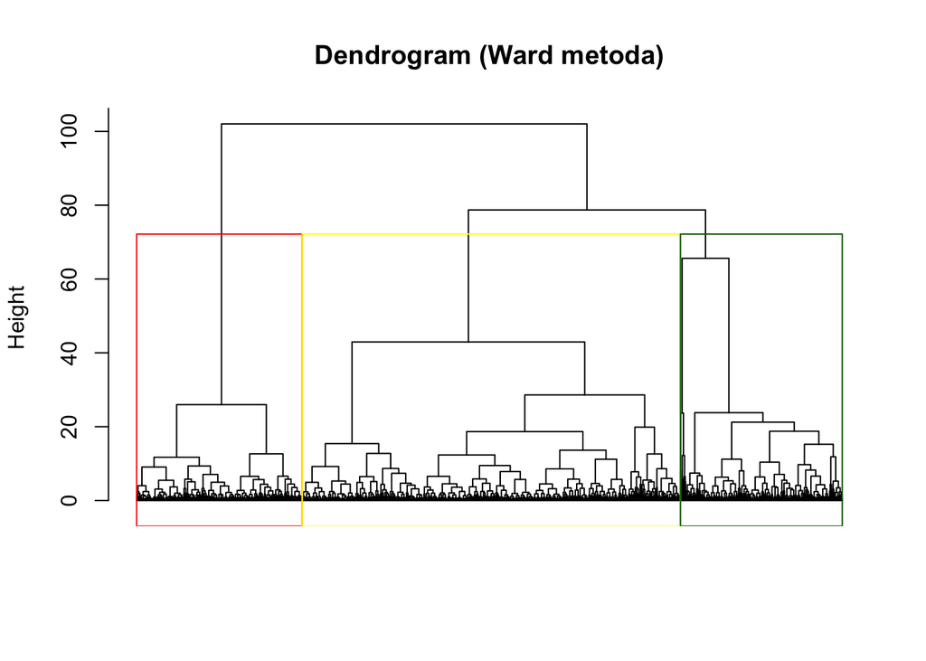

```r
#Vizualizacija dendrograma WARD
plot(
  HC_Ward,
  labels = FALSE,
  hang = -1,
  main = "Dendrogram (Ward metoda)",
  xlab = "",
  sub = "",
  cex = 0.6
)

rect.hclust(HC_Ward, k = 3, border = c("red", "yellow", "darkgreen"))
```

Wardova metoda (Ward.D2) razlikuje se od ostale dvije metode jer ne minimizira izravno udaljenost između klastera. Ovdje smo koristili logaritmirane podatke, pa je struktura stabla puno uravnoteženija nego da smo koristili sirove podatke, što nam olakšava odluku na 3 grupe. Wardova metoda nastoji formirati klastere koji su što sličniji unutar sebe, a što različitiji međusobno.

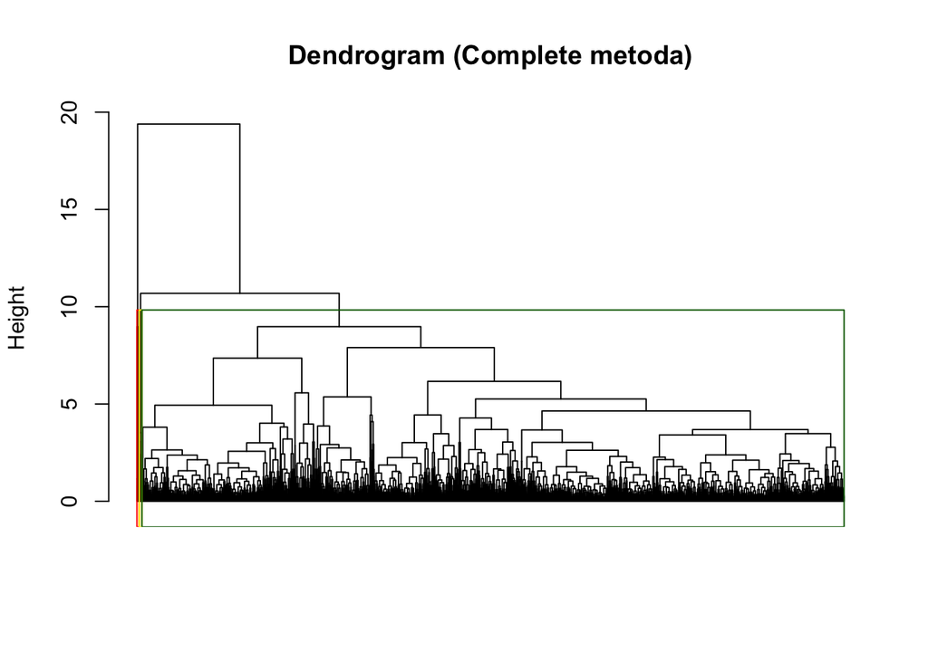

```r
#Vizualizacija dendrograma COMPLETE
plot(
  HC_Complete,
  labels = FALSE,
  hang = -1,
  main = "Dendrogram (Complete metoda)",
  xlab = "",
  sub = "",
  cex = 0.6
)

rect.hclust(HC_Complete, k = 3, border = c("red", "yellow", "darkgreen"))
```

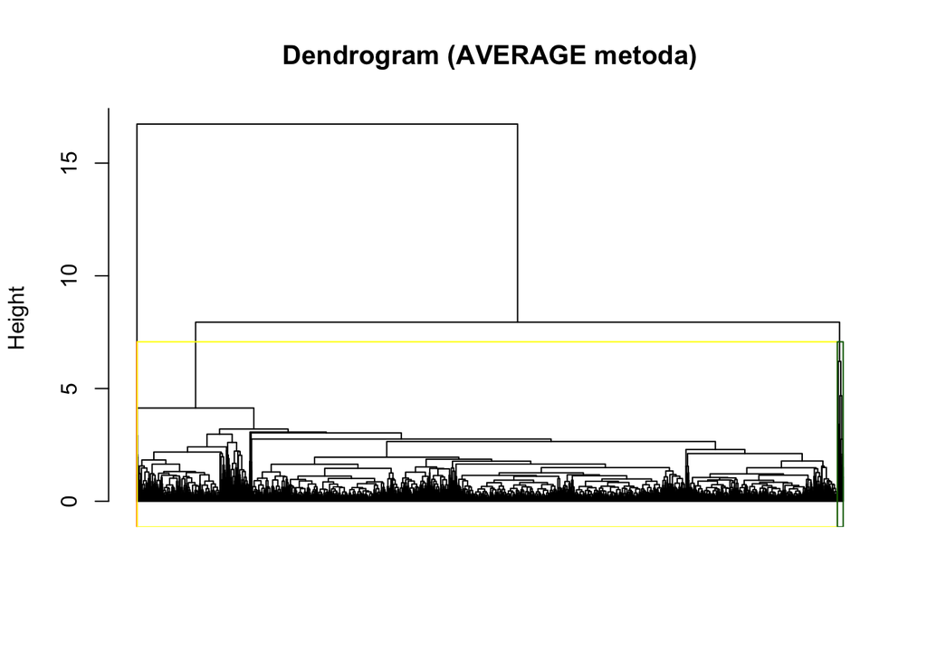

```r
#Vizualizacija dendrograma AVERAGE
plot(
  HC_Average,
  labels = FALSE,
  hang = -1,
  main = "Dendrogram (AVERAGE metoda)",
  xlab = "",
  sub = "",
  cex = 0.6
)

rect.hclust(HC_Average, k = 3, border = c("red", "yellow", "darkgreen"))
```

Average metoda računa udaljenost između klastera kao prosječnu udaljenost svih parova točaka iz dvaju klastera. Ova metoda predstavlja kompromis single i complete metoda te daje uravnoteženije klastere. U našem slučaju average metoda daje nešto stabilniju strukturu dendrograma u odnosu na complete metodu, ali i dalje postoji velika zbijenost u donjem dijelu stabla zbog velikog broja kupaca.

Dendrogram dobiven Wardovom metodom pokazuje najsloženiju, ali i najinformativniju strukturu, s jasnim razinama spajanja klastera. Za razliku od complete i average metode, ovdje se vide skokovi u visini stabla, što olakšava odluku o broju klastera.

Wardova metoda daje uravnotežene klastere, bez ekstremno malih ili ekstremno velikih grupa. To je važno u kontekstu analize kupaca jer želimo dobiti smislen broj segmenata koji se mogu interpretirati i usporediti s rezultatima dobivenim metodom k-sredina.

Rezultati Wardove metode pokazuju veliku konzistentnost s rezultatima k-means grupiranja iz prethodnog zadatka. Kada se dendrogram presiječe na tri klastera, dobivene skupine odgovaraju segmentima koje smo već identificirali metodom k-sredina (aktivni kupci, povremeni kupci i neaktivni kupci). To potvrđuje stabilnost i zašto bi trebali koristiti ovu metodu. Wardova metoda se pokazala kao najprikladniji izbor za hijerarhijsko grupiranje u ovom zadatku te je korištena za donošenje daljnjih zaključaka i usporedbu s rezultatima k-sredina.

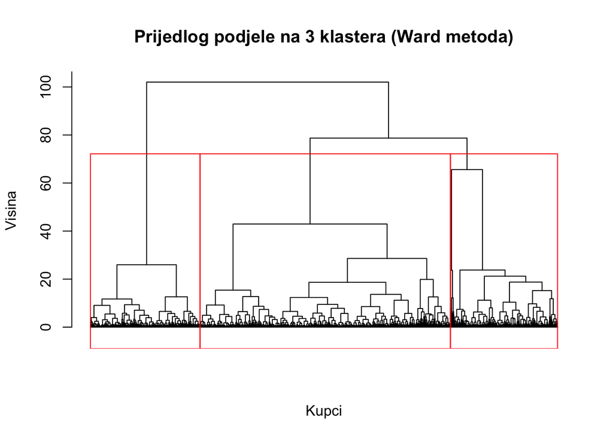

```r
#Odabir broja klastera i vizualizacija odluke
k_odabir <- 3

plot(HC_Ward,
     labels = FALSE,
     hang = -1,
     main = paste("Prijedlog podjele na", k_odabir, "klastera (Ward metoda)"),
     xlab = "Kupci",
     sub = "",
     ylab = "Visina")

rect.hclust(HC_Ward, k = k_odabir, border = "red")
```

```r
GrupeHC <- cutree(HC_Ward, k = k_odabir) #koliko kupaca je u kojem klasteru
print("Veličine klastera dobivene hijerarhijskim grupiranjem:")
```

```
## [1] "Veličine klastera dobivene hijerarhijskim grupiranjem:"
```

```r
table(GrupeHC)
```

```
## GrupeHC
##    1    2    3
## 2271  972  994
```

Nakon što smo proveli hijerarhijsko grupiranje, odlučili smo se za podjelu podataka na 3 klastera. Promatrajući dendrogram dobiven Wardovom metodom, uočili smo da su te tri grupe vrlo jasno vizualno odvojene. Vertikalne linije na grafu su prilično dugačke prije nego što se stablo počne granati na sitnije dijelove, što nam pokazuje da su te tri cjeline međusobno dovoljno različite. Da smo išli na podjelu od 4 ili više grupa, te razlike bi bile znatno manje, a podgrupe previše slične.

```r
UsporedbaTablica <- table(K_means = KmeansFinalNorm$cluster, Hijerarhijsko = GrupeHC)

print("Usporedba pripadnosti klasterima (K-sredina vs. Ward):")
```

```
## [1] "Usporedba pripadnosti klasterima (K-sredina vs. Ward):"
```

```r
print(UsporedbaTablica)
```

```
##        Hijerarhijsko
## K_means    1    2    3
##       1 2184   48  535
##       2   86  920    3
##       3    1    4  456
```

```r
AtributiSklasteromHC <- AtributiBezStrsila %>%
  mutate(KlasterHC = GrupeHC)

ProfilKlasteraHC <- AtributiSklasteromHC %>%
  group_by(KlasterHC) %>%
  summarise(
    BrojKupaca = n(),
    UkupnaPotrosnja = mean(UkupnaPotrosnja),
    BrojRacuna = mean(BrojRacuna),
    DaniOdZadnjeKupnje = mean(DaniOdZadnjeKupnje),
    .groups = "drop"
  )

print("Profil kupaca prema Hijerarhijskom grupiranju:")
```

```
## [1] "Profil kupaca prema Hijerarhijskom grupiranju:"
```

```r
print(ProfilKlasteraHC)
```

```
## # A tibble: 3 × 5
##   KlasterHC BrojKupaca UkupnaPotrosnja BrojRacuna DaniOdZadnjeKupnje
##       <int>      <int>           <dbl>      <dbl>              <dbl>
## 1         1       2271            741.       2.41              5569.
## 2         2        972            462.       1.42              5759.
## 3         3        994           3753.       9.11              5544.
```

Nakon što smo proveli oba načina grupiranja, usporedili smo rezultate i zaključili da se oni u velikoj mjeri podudaraju. Kada smo napravili tablicu usporedbe, vidjeli smo da većina kupaca koja je kod k-sredina završila u jednoj grupi, kod hijerarhijskog grupiranja također završava zajedno. Iako se oznake klastera (brojevi 1, 2, 3) možda ne zovu isto, sastav grupa je vrlo sličan. To nam je dovoljan pokazatelj da potvrdi da nismo dobili slučajne rezultate, već da u podacima stvarno postoje te grupe.

Što se tiče opisa navika kupaca, razlika nema. I kod hijerarhijskog grupiranja, kada pogledamo prosječne vrijednosti, ponovno dobivamo tri ista profila koja smo vidjeli i ranije: jednu grupu aktivnih kupaca koji troše puno, jednu grupu onih koji nas dugo nisu posjetili i srednju grupu redovnih kupaca s manjom potrošnjom. Bez obzira koju metodu koristili, zaključak ostaje isti.